# Ficha de Información Metropolitana

Universidad Autónoma Metropolitnana

Lic. Martínez Rodriguez, Alvaro[^1]

Lic. Pérez Victorino, Leonardo[^2]

La ficha de información metropolitana es una herramienta valiosa para la planificación territorial en zonas metropolitanas (ZM). Proporciona información censal en diferentes formatos, como gráficos, tablas y mapas, tanto de los Censos de Población y Vivienda, 2020 (CPV2020) como de los Censos Económicos de 1999, 2004, 2009, 2014 y 2019. Ambos publicados por el Instituto Nacional de Estadística y Geografía (INEGI).

## Información general de la Zona Metropolitana de Monclova-Frontera

Según (Sedatu 2018), la zona metropolitana se define como un área urbana que consta de una ciudad principal y su zona conurbada. Las zonas metropolitanas se caracterizan por tener una alta densidad de población y estar interconectadas por vías de transporte y comunicación. La zona metropolitana de Monclova-Frontera, se localiza en Coahuila de Zaragoza. y esta compuesta por 4 municipios, que se muestran a continuación:

| Nombre | Clave |
| --- | --- |
| Castaños | 05006 |
| Frontera | 05010 |
| Monclova | 05018 |
| San Buenaventura | 05031 |

Municipios de la zona metropolitana

Además, se presenta un mapa de la zona metropolitana:

[interactive chart not shown]

A continuación se presentan algunos datos generales sobre esta zona:

- Zona Metropolitana:Monclova-Frontera
- Número de municipios: 4
- Población total: 374,247
- Superficie de la ZM: 11,421.81 [m^2]
- Densidad poblacional: 32.766 [1/m^2] Hab/Km^2.
- Grado promedio de escolaridad: 10.1775

## Información sociodemográfica

La estructura de población de la zona metropolitana de Monclova-Frontera se presenta en la una piramide poblacional ya que permite obtener una visión general de la distribución de la población por género y edad:

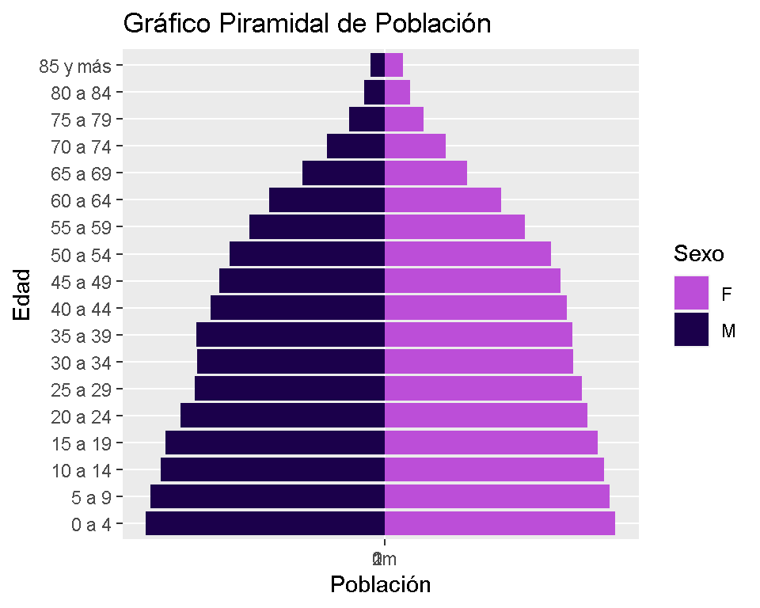

En el siguiente mapa se observa como se distribuye la población sobre la región:

[interactive chart not shown]

### Grupos de población

- Población total respecto al país: 0%. Este valor indica el peso poblacional de la zona metropolitana en relación con la población total de México.
- Población Masculina: 50%
- Población Femenina: 50%
- Relación M-F: 99.315. Este valor indica la proporción de hombres por cada mujer en la zona metropolitana.

### Socioeconómicos

La población en terminos de la poblacioón economicamente activa esta descrita por:

- Porcentaje de población de 12 años y más económicamente activa: 45%
- Porcentaje de población de 12 años y más no económicamente activa: 34% `

### Educación

La educación de la zona metropolitana esta caracterizada por los siguientes estadísticos:

- Porcentaje de población de 15 años y más sin escolaridad:1%
- Porcentaje de población de 15 años y más con al menos un grado aprobado en primaria: 66%
- Porcentaje de población de 15 años y más con educación básica completa: 21%
- Porcentaje de población de 15 años y más con secundaria o equivalente incompleta:2%
- Porcentaje de población de 18 años y más con al menos un grado aprobado en educación media superior: 35%

### Salud

La situación de la afiliación a algún servico de salud es la siguiente:

- Porcentaje de población afiliada a servicios de salud: 84%
- Población sin afiliación a servicios de salud:58493

### Indicadores de desarrollo

Finalmente se presentan tres indicadores de desarrollo; los índices son: índice de Desarrollo Humano (IDH), Índice de Marginación (IM) e Índice de Rezago Social (IRS).

IDH es un indicador elaborado por el Programa de Naciones Unidas para el Desarrollo (PNUD), este busca medir la calidad de vida, así como el progreso socioeconómico de cada entidad y municipio; El cálculo del Índice de Desarrollo Humano se realiza a partir de las tres variables: esperanza de vida, educación e ingreso per cápita.

- Muy Alto - IDH mayor de 1.
- Alto - IDH entre 0.80 a 1.
- Medio - IDH entre 0.50 y 0.80.
- Bajo - IDH entre 0 y 0.50
- Muy Bajo - IDH menores a 0.
- El promedio del IDH en 2020 para la zona metropolitana es de 0.773 según datos del PNUD.

El IM es un índice construido por el consejo Nacional de Población (CONAPO). Este índice considera 4 dimensiones estructurales para su construcción: vivienda, ingreso, educación y distribución de la población. El indice se puede ubicar en 5 estratos designados por la ténica de estratificación de Dalenius-Hodges..

Por último, el IRS es construido por el Consejo Nacional de Evaluación de la Política de Desarrollo Social, CONEVAL, este índice incorpora indicadores de educación, de acceso a servicios de salud, de servicios básicos y tiene como finalidad ordenar los municipios según sus carencias sociales. Este índice, al igual que el IM, se clasifica en cinco estratos.

## Datos económicos.

Con base en la información de los subsectores de los 21 sectores principales de la clasificación del SCIAN, extraída de los Censos Económicos del INEGI durante el periodo de 1998-2018, se ha llevado a cabo la agrupación de los datos de cada municipio que pertenece a una zona metropolitana en cinco grandes sectores: Primarios, Construcción, Manufactura, Comercio y Servicios. Esta clasificación se basa en la metodología proporcionada por el INEGI. Se utilizaron las siguientes variables:

- Unidades económicas (UE) [número de unidades]
- Activiso fijos totales (AF) [miles de pesos a precios corrientes]
- Formación bruta de capital fijo (FB) [miles de pesos a precios corrientes]
- Producción bruta total (PB) [miles de pesos a precios corrientes]
- Personal ocupado total (PO) [número de personas]
- Total de remuneraciones (RE) [miles de pesos a precios corrientes]
- Valor agregado censal bruto (VA) [miles de pesos a precios corrientes]

Posteriormente, se replica la metodología utilizada por García y Carranco (2008) para estimar los coeficientes de participación relativa (PR), de localización de la actividad económica (QL), Hirschman-Herfindahl (HH) e Inverso de Hirschman-Herfindahl (IHH).

$PR_ij$=$X_ij/X_in$

$QL_ij$=$(X_ij⁄X_j )/(X_in⁄X_n)$

$HH_ij$=$X_ij/X_in - X_j/X_n$

$IHH_ij$=$1/(X_ij/X_in - X_j/X_n)$

Donde:

### Cifras brutas

#### 1999

##### UE

| Clave | Municipio | Primarios | Construcción | Manufactura | Comercio | Servicios |
| --- | --- | --- | --- | --- | --- | --- |
| 05006 | Castaños | 0 | 0 | 42 | 297 | 91 |
| 05010 | Frontera | 0 | 0 | 148 | 1,238 | 416 |
| 05018 | Monclova | 0 | 81 | 582 | 3,178 | 2,158 |
| 05031 | San Buenaventura | 0 | 0 | 49 | 369 | 119 |

##### AF

| Clave | Municipio | Primarios | Construcción | Manufactura | Comercio | Servicios |
| --- | --- | --- | --- | --- | --- | --- |
| 05006 | Castaños | 117,825 | 3,023 | 215,965 | 33,113 | 42,942 |
| 05010 | Frontera | 0 | 15,486 | 1,615,747 | 253,106 | 837,846 |
| 05018 | Monclova | 203,845 | 230,629 | 6,790,592 | 605,110 | 879,071 |
| 05031 | San Buenaventura | 0 | 7 | 7,833 | 21,557 | 24,659 |

##### FB

| Clave | Municipio | Primarios | Construcción | Manufactura | Comercio | Servicios |
| --- | --- | --- | --- | --- | --- | --- |
| 05006 | Castaños | 30,064 | 252 | 69,692 | 1,927 | 2,436 |
| 05010 | Frontera | 0 | 2,733 | 528,281 | 145,520 | 12,110 |
| 05018 | Monclova | 6,651 | 28,297 | 310,526 | 22,360 | 77,259 |
| 05031 | San Buenaventura | 0 | 0 | 57 | 594 | 664 |

##### PB

| Clave | Municipio | Primarios | Construcción | Manufactura | Comercio | Servicios |
| --- | --- | --- | --- | --- | --- | --- |
| 05006 | Castaños | 60,358 | 22,781 | 379,481 | 64,575 | 62,495 |
| 05010 | Frontera | 0 | 49,733 | 3,334,157 | 228,300 | 488,827 |
| 05018 | Monclova | 1,593,336 | 699,409 | 18,544,747 | 1,136,301 | 2,126,564 |
| 05031 | San Buenaventura | 0 | 8 | 12,771 | 43,391 | 21,789 |

##### PO

| Clave | Municipio | Primarios | Construcción | Manufactura | Comercio | Servicios |
| --- | --- | --- | --- | --- | --- | --- |
| 05006 | Castaños | 173 | 167 | 1,189 | 656 | 527 |
| 05010 | Frontera | 0 | 495 | 8,198 | 2,800 | 2,539 |
| 05018 | Monclova | 899 | 7,508 | 14,331 | 10,182 | 15,870 |
| 05031 | San Buenaventura | 0 | 1 | 163 | 780 | 413 |

##### RE

| Clave | Municipio | Primarios | Construcción | Manufactura | Comercio | Servicios |
| --- | --- | --- | --- | --- | --- | --- |
| 05006 | Castaños | 6,264 | 5,334 | 55,104 | 5,178 | 7,840 |
| 05010 | Frontera | 0 | 11,507 | 363,409 | 30,290 | 73,363 |
| 05018 | Monclova | 98,737 | 119,033 | 1,182,574 | 184,385 | 768,579 |
| 05031 | San Buenaventura | 0 | 0 | 1,079 | 6,903 | 2,669 |

##### VA

| Clave | Municipio | Primarios | Construcción | Manufactura | Comercio | Servicios |
| --- | --- | --- | --- | --- | --- | --- |
| 05006 | Castaños | 31,033 | 9,825 | 126,188 | 31,678 | 24,876 |
| 05010 | Frontera | 0 | 16,171 | 1,366,264 | 171,723 | 201,414 |
| 05018 | Monclova | 238,598 | 175,572 | 6,573,873 | 824,926 | 1,280,996 |
| 05031 | San Buenaventura | 0 | 6 | 4,637 | 30,754 | 10,863 |

#### 2004

##### UE

| Clave | Municipio | Primarios | Construcción | Manufactura | Comercio | Servicios |
| --- | --- | --- | --- | --- | --- | --- |
| 05006 | Castaños | 0 | 0 | 29 | 290 | 71 |
| 05010 | Frontera | 0 | 0 | 126 | 1,100 | 358 |
| 05018 | Monclova | 0 | 40 | 566 | 3,394 | 2,420 |
| 05031 | San Buenaventura | 0 | 0 | 41 | 348 | 98 |

##### AF

| Clave | Municipio | Primarios | Construcción | Manufactura | Comercio | Servicios |
| --- | --- | --- | --- | --- | --- | --- |
| 05006 | Castaños | 10,768 | 0 | 487,418 | 25,211 | 113,457 |
| 05010 | Frontera | 0 | 5,861 | 2,266,764 | 294,064 | 108,049 |
| 05018 | Monclova | 247,174 | 296,557 | 12,202,032 | 765,013 | 1,417,058 |
| 05031 | San Buenaventura | 0 | 260 | 46,341 | 47,880 | 23,294 |

##### FB

| Clave | Municipio | Primarios | Construcción | Manufactura | Comercio | Servicios |
| --- | --- | --- | --- | --- | --- | --- |
| 05006 | Castaños | 20 | 0 | 41,998 | 314 | 6,552 |
| 05010 | Frontera | 0 | 929 | 76,623 | 9,514 | 2,668 |
| 05018 | Monclova | 208 | 9,622 | 115,548 | 31,027 | 43,481 |
| 05031 | San Buenaventura | 0 | 0 | 5,768 | 2,311 | 627 |

##### PB

| Clave | Municipio | Primarios | Construcción | Manufactura | Comercio | Servicios |
| --- | --- | --- | --- | --- | --- | --- |
| 05006 | Castaños | 35,487 | 0 | 913,388 | 48,896 | 138,455 |
| 05010 | Frontera | 0 | 16,498 | 4,392,295 | 773,269 | 169,246 |
| 05018 | Monclova | 1,526,063 | 540,764 | 13,966,081 | 1,781,068 | 2,416,507 |
| 05031 | San Buenaventura | 0 | 238 | 106,924 | 72,284 | 31,055 |

##### PO

| Clave | Municipio | Primarios | Construcción | Manufactura | Comercio | Servicios |
| --- | --- | --- | --- | --- | --- | --- |
| 05006 | Castaños | 84 | 0 | 2,552 | 699 | 670 |
| 05010 | Frontera | 0 | 79 | 9,124 | 3,606 | 2,156 |
| 05018 | Monclova | 282 | 3,328 | 13,407 | 13,230 | 16,010 |
| 05031 | San Buenaventura | 0 | 4 | 1,282 | 1,091 | 383 |

##### RE

| Clave | Municipio | Primarios | Construcción | Manufactura | Comercio | Servicios |
| --- | --- | --- | --- | --- | --- | --- |
| 05006 | Castaños | 5,978 | 0 | 195,783 | 8,600 | 36,055 |
| 05010 | Frontera | 0 | 2,124 | 613,641 | 70,510 | 72,420 |
| 05018 | Monclova | 57,569 | 101,391 | 1,595,738 | 320,627 | 936,219 |
| 05031 | San Buenaventura | 0 | 59 | 61,527 | 16,158 | 5,974 |

##### VA

| Clave | Municipio | Primarios | Construcción | Manufactura | Comercio | Servicios |
| --- | --- | --- | --- | --- | --- | --- |
| 05006 | Castaños | 26,284 | 0 | 421,444 | 35,553 | 85,633 |
| 05010 | Frontera | 0 | 8,097 | 1,371,920 | 588,765 | 111,921 |
| 05018 | Monclova | 566,450 | 238,751 | 3,810,973 | 1,143,132 | 1,425,471 |
| 05031 | San Buenaventura | 0 | 70 | 78,839 | 48,406 | 16,403 |

#### 2009

##### UE

| Clave | Municipio | Primarios | Construcción | Manufactura | Comercio | Servicios |
| --- | --- | --- | --- | --- | --- | --- |
| 05006 | Castaños | 0 | 0 | 54 | 351 | 106 |
| 05010 | Frontera | 0 | 8 | 271 | 1,299 | 657 |
| 05018 | Monclova | 0 | 105 | 841 | 3,702 | 2,918 |
| 05031 | San Buenaventura | 0 | 0 | 37 | 370 | 95 |

##### AF

| Clave | Municipio | Primarios | Construcción | Manufactura | Comercio | Servicios |
| --- | --- | --- | --- | --- | --- | --- |
| 05006 | Castaños | 2,365,154 | 165 | 1,117,139 | 81,856 | 182,360 |
| 05010 | Frontera | 0 | 26,176 | 3,623,553 | 442,612 | 993,276 |
| 05018 | Monclova | 1,175,155 | 342,594 | 17,950,224 | 1,335,623 | 2,313,585 |
| 05031 | San Buenaventura | 0 | 2,185 | 16,517 | 117,357 | 37,330 |

##### FB

| Clave | Municipio | Primarios | Construcción | Manufactura | Comercio | Servicios |
| --- | --- | --- | --- | --- | --- | --- |
| 05006 | Castaños | 262 | 40 | 93,432 | 7,281 | 6,086 |
| 05010 | Frontera | 0 | 106 | 192,800 | 15,220 | 259,315 |
| 05018 | Monclova | 52,141 | 16,549 | 710,640 | 116,849 | 144,008 |
| 05031 | San Buenaventura | 0 | 562 | 8 | 8,623 | 140 |

##### PB

| Clave | Municipio | Primarios | Construcción | Manufactura | Comercio | Servicios |
| --- | --- | --- | --- | --- | --- | --- |
| 05006 | Castaños | 85,613 | 17,450 | 1,750,121 | 93,945 | 212,864 |
| 05010 | Frontera | 0 | 225,491 | 14,190,847 | 804,392 | 926,058 |
| 05018 | Monclova | 2,214,691 | 1,362,759 | 38,228,537 | 2,265,896 | 4,721,284 |
| 05031 | San Buenaventura | 0 | 22,174 | 122,389 | 94,348 | 35,891 |

##### PO

| Clave | Municipio | Primarios | Construcción | Manufactura | Comercio | Servicios |
| --- | --- | --- | --- | --- | --- | --- |
| 05006 | Castaños | 132 | 47 | 1,986 | 891 | 736 |
| 05010 | Frontera | 0 | 312 | 12,892 | 3,965 | 2,784 |
| 05018 | Monclova | 570 | 3,809 | 15,030 | 13,846 | 20,218 |
| 05031 | San Buenaventura | 0 | 53 | 192 | 1,132 | 499 |

##### RE

| Clave | Municipio | Primarios | Construcción | Manufactura | Comercio | Servicios |
| --- | --- | --- | --- | --- | --- | --- |
| 05006 | Castaños | 15,969 | 2,170 | 194,366 | 12,061 | 34,059 |
| 05010 | Frontera | 0 | 18,627 | 1,430,522 | 94,024 | 179,829 |
| 05018 | Monclova | 117,701 | 192,633 | 2,641,020 | 394,905 | 1,480,436 |
| 05031 | San Buenaventura | 0 | 3,027 | 5,881 | 20,997 | 5,846 |

##### VA

| Clave | Municipio | Primarios | Construcción | Manufactura | Comercio | Servicios |
| --- | --- | --- | --- | --- | --- | --- |
| 05006 | Castaños | 33,832 | 3,661 | 553,596 | 59,639 | 119,711 |
| 05010 | Frontera | 0 | 51,124 | 5,090,859 | 479,585 | 323,065 |
| 05018 | Monclova | 1,376,668 | 497,560 | 10,539,319 | 1,285,212 | 2,605,393 |
| 05031 | San Buenaventura | 0 | 3,046 | 27,653 | 58,906 | 20,994 |

#### 2014

##### UE

| Clave | Municipio | Primarios | Construcción | Manufactura | Comercio | Servicios |
| --- | --- | --- | --- | --- | --- | --- |
| 05006 | Castaños | 0 | 0 | 78 | 413 | 158 |
| 05010 | Frontera | 0 | 8 | 237 | 1,103 | 649 |
| 05018 | Monclova | 0 | 68 | 888 | 3,448 | 3,131 |
| 05031 | San Buenaventura | 0 | 0 | 69 | 458 | 272 |

##### AF

| Clave | Municipio | Primarios | Construcción | Manufactura | Comercio | Servicios |
| --- | --- | --- | --- | --- | --- | --- |
| 05006 | Castaños | 0 | 0 | 43,861 | 125,983 | 19,870 |
| 05010 | Frontera | 0 | 3,656 | 4,643,941 | 740,698 | 186,126 |
| 05018 | Monclova | 0 | 412,612 | 63,864,217 | 2,213,946 | 2,290,856 |
| 05031 | San Buenaventura | 0 | 0 | 31,378 | 115,629 | 70,182 |

##### FB

| Clave | Municipio | Primarios | Construcción | Manufactura | Comercio | Servicios |
| --- | --- | --- | --- | --- | --- | --- |
| 05006 | Castaños | 0 | 0 | 10,745 | 4,063 | 304 |
| 05010 | Frontera | 0 | -3 | 731,525 | 22,444 | 3,933 |
| 05018 | Monclova | 0 | 9,374 | 8,845,729 | 109,241 | 127,570 |
| 05031 | San Buenaventura | 0 | 0 | 19 | 6,963 | 27 |

##### PB

| Clave | Municipio | Primarios | Construcción | Manufactura | Comercio | Servicios |
| --- | --- | --- | --- | --- | --- | --- |
| 05006 | Castaños | 0 | 0 | 137,489 | 128,172 | 21,072 |
| 05010 | Frontera | 0 | 20,899 | 17,903,190 | 1,276,724 | 310,951 |
| 05018 | Monclova | 0 | 822,752 | 42,614,124 | 3,018,200 | 4,622,551 |
| 05031 | San Buenaventura | 0 | 0 | 128,106 | 119,948 | 43,651 |

##### PO

| Clave | Municipio | Primarios | Construcción | Manufactura | Comercio | Servicios |
| --- | --- | --- | --- | --- | --- | --- |
| 05006 | Castaños | 0 | 0 | 629 | 992 | 270 |
| 05010 | Frontera | 0 | 111 | 17,304 | 3,926 | 1,977 |
| 05018 | Monclova | 0 | 2,294 | 18,969 | 13,397 | 21,309 |
| 05031 | San Buenaventura | 0 | 0 | 190 | 1,100 | 458 |

##### RE

| Clave | Municipio | Primarios | Construcción | Manufactura | Comercio | Servicios |
| --- | --- | --- | --- | --- | --- | --- |
| 05006 | Castaños | 0 | 0 | 34,230 | 18,122 | 2,189 |
| 05010 | Frontera | 0 | 5,433 | 1,887,939 | 143,046 | 57,202 |
| 05018 | Monclova | 0 | 152,417 | 4,291,328 | 531,632 | 1,990,409 |
| 05031 | San Buenaventura | 0 | 0 | 6,800 | 30,119 | 4,735 |

##### VA

| Clave | Municipio | Primarios | Construcción | Manufactura | Comercio | Servicios |
| --- | --- | --- | --- | --- | --- | --- |
| 05006 | Castaños | 0 | 0 | 56,902 | 92,741 | 12,029 |
| 05010 | Frontera | 0 | 11,393 | 4,537,917 | 956,546 | 136,771 |
| 05018 | Monclova | 0 | 290,231 | 21,634,816 | 2,005,440 | 2,886,491 |
| 05031 | San Buenaventura | 0 | 0 | 26,024 | 84,603 | 21,939 |

#### 2019

##### UE

| Clave | Municipio | Primarios | Construcción | Manufactura | Comercio | Servicios |
| --- | --- | --- | --- | --- | --- | --- |
| 05006 | Castaños | 4 | 1 | 123 | 444 | 328 |
| 05010 | Frontera | 0 | 11 | 387 | 1,267 | 919 |
| 05018 | Monclova | 7 | 98 | 1,076 | 3,911 | 3,673 |
| 05031 | San Buenaventura | 1 | 3 | 99 | 415 | 295 |

##### AF

| Clave | Municipio | Primarios | Construcción | Manufactura | Comercio | Servicios |
| --- | --- | --- | --- | --- | --- | --- |
| 05006 | Castaños | 54,308 | 0 | 3,824,722 | 1,926,248 | 784,646 |
| 05010 | Frontera | 0 | 0 | 7,670,492 | 857,058 | 302,062 |
| 05018 | Monclova | 0 | 532,105 | 83,427,172 | 5,358,325 | 3,738,286 |
| 05031 | San Buenaventura | 0 | 0 | 57,460 | 100,934 | 19,376 |

##### FB

| Clave | Municipio | Primarios | Construcción | Manufactura | Comercio | Servicios |
| --- | --- | --- | --- | --- | --- | --- |
| 05006 | Castaños | 0 | 0 | 247,540 | 37,734 | 58,450 |
| 05010 | Frontera | 0 | 0 | 882,316 | -419,133 | 11,601 |
| 05018 | Monclova | 0 | 14,538 | 1,525,628 | 404,694 | 90,803 |
| 05031 | San Buenaventura | 0 | 0 | 256 | 6,680 | 809 |

##### PB

| Clave | Municipio | Primarios | Construcción | Manufactura | Comercio | Servicios |
| --- | --- | --- | --- | --- | --- | --- |
| 05006 | Castaños | 78,762 | 0 | 5,465,489 | 241,359 | 980,619 |
| 05010 | Frontera | 0 | 0 | 37,415,196 | 1,895,740 | 605,659 |
| 05018 | Monclova | 0 | 2,011,604 | 85,856,980 | 8,113,422 | 7,668,853 |
| 05031 | San Buenaventura | 0 | 0 | 261,623 | 263,870 | 75,018 |

##### PO

| Clave | Municipio | Primarios | Construcción | Manufactura | Comercio | Servicios |
| --- | --- | --- | --- | --- | --- | --- |
| 05006 | Castaños | 93 | 0 | 2,374 | 1,154 | 2,012 |
| 05010 | Frontera | 0 | 0 | 23,939 | 4,546 | 2,700 |
| 05018 | Monclova | 0 | 3,521 | 23,703 | 16,778 | 24,634 |
| 05031 | San Buenaventura | 0 | 0 | 373 | 1,267 | 563 |

##### RE

| Clave | Municipio | Primarios | Construcción | Manufactura | Comercio | Servicios |
| --- | --- | --- | --- | --- | --- | --- |
| 05006 | Castaños | 14,754 | 0 | 30,199 | 40,556 | 182,391 |
| 05010 | Frontera | 0 | 0 | 3,325,933 | 231,651 | 81,968 |
| 05018 | Monclova | 0 | 225,366 | 5,709,518 | 853,981 | 1,668,358 |
| 05031 | San Buenaventura | 0 | 0 | 24,820 | 45,902 | 10,053 |

##### VA

| Clave | Municipio | Primarios | Construcción | Manufactura | Comercio | Servicios |
| --- | --- | --- | --- | --- | --- | --- |
| 05006 | Castaños | 33,939 | 0 | 1,272,092 | 177,811 | 491,865 |
| 05010 | Frontera | 0 | 0 | 12,944,481 | 1,215,370 | 261,770 |
| 05018 | Monclova | 0 | 839,219 | 31,841,733 | 5,671,711 | 3,860,260 |
| 05031 | San Buenaventura | 0 | 0 | 107,361 | 180,450 | 37,652 |

### Coeficientes de localización (QL)

#### 1999

##### UE

| Clave | Municipio | Primarios | Construcción | Manufactura | Comercio | Servicios |
| --- | --- | --- | --- | --- | --- | --- |
| 05006 | Castaños | 0.0000 | 0.0000 | 0.8803 | 1.3091 | 0.5998 |
| 05010 | Frontera | 0.0000 | 0.0000 | 0.7402 | 1.3021 | 0.6543 |
| 05018 | Monclova | 0.0000 | 2.2705 | 0.8744 | 1.0040 | 1.0196 |
| 05031 | San Buenaventura | 0.0000 | 0.0000 | 0.8224 | 1.3024 | 0.6281 |

##### AF

| Clave | Municipio | Primarios | Construcción | Manufactura | Comercio | Servicios |
| --- | --- | --- | --- | --- | --- | --- |
| 05006 | Castaños | 11.7259 | 0.4809 | 1.5374 | 1.0560 | 0.1911 |
| 05010 | Frontera | 0.0000 | 0.3736 | 1.7445 | 1.2242 | 0.5655 |
| 05018 | Monclova | 0.9617 | 1.7392 | 2.2916 | 0.9148 | 0.1855 |
| 05031 | San Buenaventura | 0.0000 | 0.0085 | 0.4259 | 5.2507 | 0.8382 |

##### FB

[output not shown]

##### PB

| Clave | Municipio | Primarios | Construcción | Manufactura | Comercio | Servicios |
| --- | --- | --- | --- | --- | --- | --- |
| 05006 | Castaños | 10.2570 | 1.0706 | 1.3005 | 0.7837 | 0.3318 |
| 05010 | Frontera | 0.0000 | 0.3361 | 1.6430 | 0.3984 | 0.3732 |
| 05018 | Monclova | 6.6251 | 0.8043 | 1.5551 | 0.3374 | 0.2763 |
| 05031 | San Buenaventura | 0.0000 | 0.0028 | 0.3311 | 3.9832 | 0.8751 |

##### PO

| Clave | Municipio | Primarios | Construcción | Manufactura | Comercio | Servicios |
| --- | --- | --- | --- | --- | --- | --- |
| 05006 | Castaños | 7.1915 | 1.1467 | 1.4203 | 0.9322 | 0.5262 |
| 05010 | Frontera | 0.0000 | 0.6569 | 1.8926 | 0.7690 | 0.4900 |
| 05018 | Monclova | 2.0773 | 2.8656 | 0.9515 | 0.8043 | 0.8808 |
| 05031 | San Buenaventura | 0.0000 | 0.0137 | 0.3891 | 2.2153 | 0.8242 |

##### RE

| Clave | Municipio | Primarios | Construcción | Manufactura | Comercio | Servicios |
| --- | --- | --- | --- | --- | --- | --- |
| 05006 | Castaños | 6.9288 | 2.6036 | 1.8695 | 0.4574 | 0.2180 |
| 05010 | Frontera | 0.0000 | 0.9356 | 2.0538 | 0.4457 | 0.3397 |
| 05018 | Monclova | 3.6998 | 1.9682 | 1.3591 | 0.5518 | 0.7238 |
| 05031 | San Buenaventura | 0.0000 | 0.0000 | 0.2740 | 4.5641 | 0.5554 |

##### VA

| Clave | Municipio | Primarios | Construcción | Manufactura | Comercio | Servicios |
| --- | --- | --- | --- | --- | --- | --- |
| 05006 | Castaños | 11.8042 | 1.9764 | 1.5317 | 0.6360 | 0.2968 |
| 05010 | Frontera | 0.0000 | 0.4143 | 2.1122 | 0.4391 | 0.3061 |
| 05018 | Monclova | 2.2315 | 0.8684 | 1.9619 | 0.4072 | 0.3758 |
| 05031 | San Buenaventura | 0.0000 | 0.0058 | 0.2721 | 2.9847 | 0.6265 |

#### 2004

##### UE

| Clave | Municipio | Primarios | Construcción | Manufactura | Comercio | Servicios |
| --- | --- | --- | --- | --- | --- | --- |
| 05006 | Castaños | 0.0000 | 0.0000 | 0.7607 | 1.3772 | 0.5120 |
| 05010 | Frontera | 0.0000 | 0.0000 | 0.8138 | 1.2862 | 0.6356 |
| 05018 | Monclova | 0.0000 | 1.2591 | 0.9020 | 0.9791 | 1.0601 |
| 05031 | San Buenaventura | 0.0000 | 0.0000 | 0.8613 | 1.3235 | 0.5659 |

##### AF

| Clave | Municipio | Primarios | Construcción | Manufactura | Comercio | Servicios |
| --- | --- | --- | --- | --- | --- | --- |
| 05006 | Castaños | 1.0167 | 0.0000 | 2.0891 | 0.4402 | 0.3452 |
| 05010 | Frontera | 0.0000 | 0.1994 | 2.3133 | 1.2224 | 0.0783 |
| 05018 | Monclova | 0.9956 | 1.8082 | 2.2312 | 0.5698 | 0.1839 |
| 05031 | San Buenaventura | 0.0000 | 0.2009 | 1.0740 | 4.5203 | 0.3832 |

##### FB

[output not shown]

##### PB

| Clave | Municipio | Primarios | Construcción | Manufactura | Comercio | Servicios |
| --- | --- | --- | --- | --- | --- | --- |
| 05006 | Castaños | 3.0564 | 0.0000 | 1.7404 | 0.3133 | 0.3395 |
| 05010 | Frontera | 0.0000 | 0.0974 | 1.7770 | 1.0520 | 0.0881 |
| 05018 | Monclova | 7.3820 | 0.8445 | 1.4946 | 0.6410 | 0.3328 |
| 05031 | San Buenaventura | 0.0000 | 0.0357 | 1.0997 | 2.5000 | 0.4111 |

##### PO

| Clave | Municipio | Primarios | Construcción | Manufactura | Comercio | Servicios |
| --- | --- | --- | --- | --- | --- | --- |
| 05006 | Castaños | 2.5375 | 0.0000 | 2.4184 | 0.5970 | 0.4294 |
| 05010 | Frontera | 0.0000 | 0.1141 | 2.3140 | 0.8242 | 0.3698 |
| 05018 | Monclova | 0.7376 | 1.5554 | 1.1000 | 0.9783 | 0.8883 |
| 05031 | San Buenaventura | 0.0000 | 0.0313 | 1.7629 | 1.3521 | 0.3561 |

##### RE

| Clave | Municipio | Primarios | Construcción | Manufactura | Comercio | Servicios |
| --- | --- | --- | --- | --- | --- | --- |
| 05006 | Castaños | 2.5483 | 0.0000 | 2.2655 | 0.2232 | 0.3199 |
| 05010 | Frontera | 0.0000 | 0.1072 | 2.3062 | 0.5945 | 0.2087 |
| 05018 | Monclova | 2.0080 | 1.2893 | 1.5109 | 0.6810 | 0.6798 |
| 05031 | San Buenaventura | 0.0000 | 0.0270 | 2.0955 | 1.2345 | 0.1560 |

##### VA

| Clave | Municipio | Primarios | Construcción | Manufactura | Comercio | Servicios |
| --- | --- | --- | --- | --- | --- | --- |
| 05006 | Castaños | 2.8674 | 0.0000 | 2.2791 | 0.3172 | 0.3425 |
| 05010 | Frontera | 0.0000 | 0.1741 | 2.0286 | 1.4363 | 0.1224 |
| 05018 | Monclova | 4.8933 | 1.4871 | 1.6319 | 0.8076 | 0.4514 |
| 05031 | San Buenaventura | 0.0000 | 0.0218 | 1.6877 | 1.7097 | 0.2597 |

#### 2009

##### UE

| Clave | Municipio | Primarios | Construcción | Manufactura | Comercio | Servicios |
| --- | --- | --- | --- | --- | --- | --- |
| 05006 | Castaños | 0.0000 | 0.0000 | 1.0260 | 1.3509 | 0.5443 |
| 05010 | Frontera | 0.0000 | 0.6015 | 1.1772 | 1.1431 | 0.7713 |
| 05018 | Monclova | 0.0000 | 2.3319 | 1.0792 | 0.9623 | 1.0120 |
| 05031 | San Buenaventura | 0.0000 | 0.0000 | 0.7156 | 1.4495 | 0.4965 |

##### AF

| Clave | Municipio | Primarios | Construcción | Manufactura | Comercio | Servicios |
| --- | --- | --- | --- | --- | --- | --- |
| 05006 | Castaños | 33.3047 | 0.0028 | 1.1148 | 0.2323 | 0.0806 |
| 05010 | Frontera | 0.0000 | 0.3241 | 2.6640 | 0.9255 | 0.3235 |
| 05018 | Monclova | 2.6820 | 0.9333 | 2.9032 | 0.6144 | 0.1658 |
| 05031 | San Buenaventura | 0.0000 | 0.7936 | 0.3562 | 7.1977 | 0.3566 |

##### FB

[output not shown]

##### PB

| Clave | Municipio | Primarios | Construcción | Manufactura | Comercio | Servicios |
| --- | --- | --- | --- | --- | --- | --- |
| 05006 | Castaños | 2.1886 | 0.1911 | 1.6696 | 0.4157 | 0.2818 |
| 05010 | Frontera | 0.0000 | 0.3303 | 1.8110 | 0.4762 | 0.1640 |
| 05018 | Monclova | 2.5063 | 0.6607 | 1.6144 | 0.4439 | 0.2767 |
| 05031 | San Buenaventura | 0.0000 | 1.9087 | 0.9177 | 3.2816 | 0.3735 |

##### PO

| Clave | Municipio | Primarios | Construcción | Manufactura | Comercio | Servicios |
| --- | --- | --- | --- | --- | --- | --- |
| 05006 | Castaños | 4.8760 | 0.3119 | 2.2028 | 0.8264 | 0.4503 |
| 05010 | Frontera | 0.0000 | 0.3934 | 2.7176 | 0.6989 | 0.3237 |
| 05018 | Monclova | 1.4931 | 1.7923 | 1.1822 | 0.9107 | 0.8772 |
| 05031 | San Buenaventura | 0.0000 | 0.7108 | 0.4305 | 2.1222 | 0.6171 |

##### RE

| Clave | Municipio | Primarios | Construcción | Manufactura | Comercio | Servicios |
| --- | --- | --- | --- | --- | --- | --- |
| 05006 | Castaños | 4.5569 | 0.2241 | 2.2795 | 0.3658 | 0.2678 |
| 05010 | Frontera | 0.0000 | 0.2887 | 2.5183 | 0.4281 | 0.2122 |
| 05018 | Monclova | 1.7997 | 1.0657 | 1.6597 | 0.6418 | 0.6236 |
| 05031 | San Buenaventura | 0.0000 | 2.2609 | 0.4990 | 4.6073 | 0.3325 |

##### VA

| Clave | Municipio | Primarios | Construcción | Manufactura | Comercio | Servicios |
| --- | --- | --- | --- | --- | --- | --- |
| 05006 | Castaños | 1.5477 | 0.1605 | 2.0274 | 0.5367 | 0.3505 |
| 05010 | Frontera | 0.0000 | 0.2905 | 2.4163 | 0.5593 | 0.1226 |
| 05018 | Monclova | 2.9759 | 1.0309 | 1.8239 | 0.5465 | 0.3604 |
| 05031 | San Buenaventura | 0.0000 | 0.9304 | 0.7055 | 3.6926 | 0.4281 |

#### 2014

##### UE

| Clave | Municipio | Primarios | Construcción | Manufactura | Comercio | Servicios |
| --- | --- | --- | --- | --- | --- | --- |
| 05006 | Castaños | 0.0000 | 0.0000 | 1.2237 | 1.3037 | 0.5982 |
| 05010 | Frontera | 0.0000 | 0.8027 | 1.2084 | 1.1315 | 0.7985 |
| 05018 | Monclova | 0.0000 | 1.8083 | 1.2000 | 0.9375 | 1.0210 |
| 05031 | San Buenaventura | 0.0000 | 0.0000 | 0.8793 | 1.1743 | 0.8365 |

##### AF

| Clave | Municipio | Primarios | Construcción | Manufactura | Comercio | Servicios |
| --- | --- | --- | --- | --- | --- | --- |
| 05006 | Castaños | 0.0000 | 0.0000 | 0.8456 | 6.0411 | 0.1774 |
| 05010 | Frontera | 0.0000 | 0.0501 | 3.0469 | 1.2088 | 0.0565 |
| 05018 | Monclova | 0.0000 | 0.4586 | 3.3959 | 0.2928 | 0.0564 |
| 05031 | San Buenaventura | 0.0000 | 0.0000 | 0.5284 | 4.8432 | 0.5473 |

##### FB

[output not shown]

##### PB

| Clave | Municipio | Primarios | Construcción | Manufactura | Comercio | Servicios |
| --- | --- | --- | --- | --- | --- | --- |
| 05006 | Castaños | 0.0000 | 0.0000 | 0.9812 | 3.7489 | 0.2063 |
| 05010 | Frontera | 0.0000 | 0.0354 | 1.8776 | 0.5488 | 0.0447 |
| 05018 | Monclova | 0.0000 | 0.5322 | 1.7072 | 0.4956 | 0.2541 |
| 05031 | San Buenaventura | 0.0000 | 0.0000 | 0.8987 | 3.4486 | 0.4201 |

##### PO

| Clave | Municipio | Primarios | Construcción | Manufactura | Comercio | Servicios |
| --- | --- | --- | --- | --- | --- | --- |
| 05006 | Castaños | 0.0000 | 0.0000 | 1.3767 | 1.8394 | 0.3251 |
| 05010 | Frontera | 0.0000 | 0.1593 | 3.0713 | 0.5904 | 0.1930 |
| 05018 | Monclova | 0.0000 | 1.3712 | 1.4027 | 0.8393 | 0.8668 |
| 05031 | San Buenaventura | 0.0000 | 0.0000 | 0.4499 | 2.2065 | 0.5965 |

##### RE

| Clave | Municipio | Primarios | Construcción | Manufactura | Comercio | Servicios |
| --- | --- | --- | --- | --- | --- | --- |
| 05006 | Castaños | 0.0000 | 0.0000 | 1.8384 | 2.4174 | 0.0834 |
| 05010 | Frontera | 0.0000 | 0.1107 | 2.6414 | 0.4971 | 0.0567 |
| 05018 | Monclova | 0.0000 | 0.9337 | 1.8046 | 0.5553 | 0.5935 |
| 05031 | San Buenaventura | 0.0000 | 0.0000 | 0.4782 | 5.2608 | 0.2361 |

##### VA

| Clave | Municipio | Primarios | Construcción | Manufactura | Comercio | Servicios |
| --- | --- | --- | --- | --- | --- | --- |
| 05006 | Castaños | 0.0000 | 0.0000 | 1.0466 | 3.2508 | 0.1626 |
| 05010 | Frontera | 0.0000 | 0.0917 | 2.3914 | 0.9607 | 0.0530 |
| 05018 | Monclova | 0.0000 | 0.4913 | 2.3990 | 0.4238 | 0.2353 |
| 05031 | San Buenaventura | 0.0000 | 0.0000 | 0.5838 | 3.6166 | 0.3617 |

#### 2019

##### UE

| Clave | Municipio | Primarios | Construcción | Manufactura | Comercio | Servicios |
| --- | --- | --- | --- | --- | --- | --- |
| 05006 | Castaños | 1.8706 | 0.2142 | 1.3825 | 1.0518 | 0.8584 |
| 05010 | Frontera | 0.0000 | 0.8206 | 1.5151 | 1.0454 | 0.8377 |
| 05018 | Monclova | 0.3361 | 2.1554 | 1.2419 | 0.9513 | 0.9870 |
| 05031 | San Buenaventura | 0.5177 | 0.7114 | 1.2319 | 1.0883 | 0.8547 |

##### AF

| Clave | Municipio | Primarios | Construcción | Manufactura | Comercio | Servicios |
| --- | --- | --- | --- | --- | --- | --- |
| 05006 | Castaños | 0.5325 | 0.0000 | 2.0487 | 1.4932 | 0.2414 |
| 05010 | Frontera | 0.0000 | 0.0000 | 3.0666 | 0.4959 | 0.0694 |
| 05018 | Monclova | 0.0000 | 0.4681 | 3.1647 | 0.2942 | 0.0814 |
| 05031 | San Buenaventura | 0.0000 | 0.0000 | 1.1410 | 2.9004 | 0.2210 |

##### FB

[output not shown]

##### PB

| Clave | Municipio | Primarios | Construcción | Manufactura | Comercio | Servicios |
| --- | --- | --- | --- | --- | --- | --- |
| 05006 | Castaños | 2.6605 | 0.0000 | 1.6181 | 0.2552 | 0.4416 |
| 05010 | Frontera | 0.0000 | 0.0000 | 1.8777 | 0.3398 | 0.0462 |
| 05018 | Monclova | 0.0000 | 0.6819 | 1.6593 | 0.5601 | 0.2254 |
| 05031 | San Buenaventura | 0.0000 | 0.0000 | 0.8727 | 3.1440 | 0.3806 |

##### PO

| Clave | Municipio | Primarios | Construcción | Manufactura | Comercio | Servicios |
| --- | --- | --- | --- | --- | --- | --- |
| 05006 | Castaños | 4.1498 | 0.0000 | 1.7157 | 0.7929 | 0.7709 |
| 05010 | Frontera | 0.0000 | 0.0000 | 3.1252 | 0.5642 | 0.1869 |
| 05018 | Monclova | 0.0000 | 1.7865 | 1.4059 | 0.9461 | 0.7747 |
| 05031 | San Buenaventura | 0.0000 | 0.0000 | 0.6893 | 2.2260 | 0.5516 |

##### RE

| Clave | Municipio | Primarios | Construcción | Manufactura | Comercio | Servicios |
| --- | --- | --- | --- | --- | --- | --- |
| 05006 | Castaños | 16.3153 | 0.0000 | 0.3118 | 1.1190 | 1.4216 |
| 05010 | Frontera | 0.0000 | 0.0000 | 2.5275 | 0.4705 | 0.0470 |
| 05018 | Monclova | 0.0000 | 1.2764 | 1.8673 | 0.7464 | 0.4119 |
| 05031 | San Buenaventura | 0.0000 | 0.0000 | 0.8499 | 4.2005 | 0.2599 |

##### VA

| Clave | Municipio | Primarios | Construcción | Manufactura | Comercio | Servicios |
| --- | --- | --- | --- | --- | --- | --- |
| 05006 | Castaños | 3.8448 | 0.0000 | 1.8808 | 0.4076 | 0.6072 |
| 05010 | Frontera | 0.0000 | 0.0000 | 2.6219 | 0.3816 | 0.0443 |
| 05018 | Monclova | 0.0000 | 0.8888 | 2.2035 | 0.6084 | 0.2230 |
| 05031 | San Buenaventura | 0.0000 | 0.0000 | 0.9636 | 2.5108 | 0.2822 |

### Participación Relativa (PR)

#### 1999

##### UE

| Clave | Municipio | Primarios | Construcción | Manufactura | Comercio | Servicios |
| --- | --- | --- | --- | --- | --- | --- |
| 05006 | Castaños | 0.0000 | 0.0000 | 0.0002 | 0.0003 | 0.0001 |
| 05010 | Frontera | 0.0000 | 0.0000 | 0.0007 | 0.0013 | 0.0006 |
| 05018 | Monclova | 0.0000 | 0.0073 | 0.0028 | 0.0032 | 0.0033 |
| 05031 | San Buenaventura | 0.0000 | 0.0000 | 0.0002 | 0.0004 | 0.0002 |

##### AF

| Clave | Municipio | Primarios | Construcción | Manufactura | Comercio | Servicios |
| --- | --- | --- | --- | --- | --- | --- |
| 05006 | Castaños | 0.0023 | 0.0001 | 0.0003 | 0.0002 | 0e+00 |
| 05010 | Frontera | 0.0000 | 0.0005 | 0.0022 | 0.0016 | 7e-04 |
| 05018 | Monclova | 0.0040 | 0.0072 | 0.0094 | 0.0038 | 8e-04 |
| 05031 | San Buenaventura | 0.0000 | 0.0000 | 0.0000 | 0.0001 | 0e+00 |

##### FB

[output not shown]

##### PB

| Clave | Municipio | Primarios | Construcción | Manufactura | Comercio | Servicios |
| --- | --- | --- | --- | --- | --- | --- |
| 05006 | Castaños | 0.0019 | 0.0002 | 0.0002 | 0.0001 | 0.0001 |
| 05010 | Frontera | 0.0000 | 0.0004 | 0.0021 | 0.0005 | 0.0005 |
| 05018 | Monclova | 0.0499 | 0.0061 | 0.0117 | 0.0025 | 0.0021 |
| 05031 | San Buenaventura | 0.0000 | 0.0000 | 0.0000 | 0.0001 | 0.0000 |

##### PO

| Clave | Municipio | Primarios | Construcción | Manufactura | Comercio | Servicios |
| --- | --- | --- | --- | --- | --- | --- |
| 05006 | Castaños | 0.0018 | 0.0003 | 0.0003 | 0.0002 | 0.0001 |
| 05010 | Frontera | 0.0000 | 0.0008 | 0.0024 | 0.0010 | 0.0006 |
| 05018 | Monclova | 0.0091 | 0.0125 | 0.0042 | 0.0035 | 0.0039 |
| 05031 | San Buenaventura | 0.0000 | 0.0000 | 0.0000 | 0.0003 | 0.0001 |

##### RE

| Clave | Municipio | Primarios | Construcción | Manufactura | Comercio | Servicios |
| --- | --- | --- | --- | --- | --- | --- |
| 05006 | Castaños | 0.0012 | 0.0004 | 0.0003 | 0.0001 | 0.0000 |
| 05010 | Frontera | 0.0000 | 0.0009 | 0.0021 | 0.0005 | 0.0003 |
| 05018 | Monclova | 0.0184 | 0.0098 | 0.0068 | 0.0027 | 0.0036 |
| 05031 | San Buenaventura | 0.0000 | 0.0000 | 0.0000 | 0.0001 | 0.0000 |

##### VA

| Clave | Municipio | Primarios | Construcción | Manufactura | Comercio | Servicios |
| --- | --- | --- | --- | --- | --- | --- |
| 05006 | Castaños | 0.0019 | 0.0003 | 0.0003 | 0.0001 | 0.0000 |
| 05010 | Frontera | 0.0000 | 0.0005 | 0.0027 | 0.0006 | 0.0004 |
| 05018 | Monclova | 0.0149 | 0.0058 | 0.0131 | 0.0027 | 0.0025 |
| 05031 | San Buenaventura | 0.0000 | 0.0000 | 0.0000 | 0.0001 | 0.0000 |

#### 2004

##### UE

| Clave | Municipio | Primarios | Construcción | Manufactura | Comercio | Servicios |
| --- | --- | --- | --- | --- | --- | --- |
| 05006 | Castaños | 0.0000 | 0.0000 | 2e-04 | 0.0003 | 0.0001 |
| 05010 | Frontera | 0.0000 | 0.0000 | 7e-04 | 0.0010 | 0.0005 |
| 05018 | Monclova | 0.0000 | 0.0041 | 3e-03 | 0.0032 | 0.0035 |
| 05031 | San Buenaventura | 0.0000 | 0.0000 | 2e-04 | 0.0003 | 0.0001 |

##### AF

| Clave | Municipio | Primarios | Construcción | Manufactura | Comercio | Servicios |
| --- | --- | --- | --- | --- | --- | --- |
| 05006 | Castaños | 0.0002 | 0.0000 | 0.0005 | 0.0001 | 1e-04 |
| 05010 | Frontera | 0.0000 | 0.0002 | 0.0022 | 0.0011 | 1e-04 |
| 05018 | Monclova | 0.0052 | 0.0094 | 0.0116 | 0.0030 | 1e-03 |
| 05031 | San Buenaventura | 0.0000 | 0.0000 | 0.0000 | 0.0002 | 0e+00 |

##### FB

[output not shown]

##### PB

| Clave | Municipio | Primarios | Construcción | Manufactura | Comercio | Servicios |
| --- | --- | --- | --- | --- | --- | --- |
| 05006 | Castaños | 0.0007 | 0.0000 | 0.0004 | 0.0001 | 0.0001 |
| 05010 | Frontera | 0.0000 | 0.0001 | 0.0019 | 0.0011 | 0.0001 |
| 05018 | Monclova | 0.0292 | 0.0033 | 0.0059 | 0.0025 | 0.0013 |
| 05031 | San Buenaventura | 0.0000 | 0.0000 | 0.0000 | 0.0001 | 0.0000 |

##### PO

| Clave | Municipio | Primarios | Construcción | Manufactura | Comercio | Servicios |
| --- | --- | --- | --- | --- | --- | --- |
| 05006 | Castaños | 0.0008 | 0.0000 | 0.0008 | 0.0002 | 0.0001 |
| 05010 | Frontera | 0.0000 | 0.0001 | 0.0027 | 0.0010 | 0.0004 |
| 05018 | Monclova | 0.0026 | 0.0056 | 0.0039 | 0.0035 | 0.0032 |
| 05031 | San Buenaventura | 0.0000 | 0.0000 | 0.0004 | 0.0003 | 0.0001 |

##### RE

| Clave | Municipio | Primarios | Construcción | Manufactura | Comercio | Servicios |
| --- | --- | --- | --- | --- | --- | --- |
| 05006 | Castaños | 0.0009 | 0.0000 | 0.0008 | 0.0001 | 0.0001 |
| 05010 | Frontera | 0.0000 | 0.0001 | 0.0024 | 0.0006 | 0.0002 |
| 05018 | Monclova | 0.0083 | 0.0053 | 0.0062 | 0.0028 | 0.0028 |
| 05031 | San Buenaventura | 0.0000 | 0.0000 | 0.0002 | 0.0001 | 0.0000 |

##### VA

| Clave | Municipio | Primarios | Construcción | Manufactura | Comercio | Servicios |
| --- | --- | --- | --- | --- | --- | --- |
| 05006 | Castaños | 0.0007 | 0.0000 | 0.0005 | 0.0001 | 0.0001 |
| 05010 | Frontera | 0.0000 | 0.0001 | 0.0017 | 0.0012 | 0.0001 |
| 05018 | Monclova | 0.0143 | 0.0044 | 0.0048 | 0.0024 | 0.0013 |
| 05031 | San Buenaventura | 0.0000 | 0.0000 | 0.0001 | 0.0001 | 0.0000 |

#### 2009

##### UE

| Clave | Municipio | Primarios | Construcción | Manufactura | Comercio | Servicios |
| --- | --- | --- | --- | --- | --- | --- |
| 05006 | Castaños | 0.0000 | 0.0000 | 0.0002 | 0.0003 | 0.0001 |
| 05010 | Frontera | 0.0000 | 0.0006 | 0.0011 | 0.0011 | 0.0007 |
| 05018 | Monclova | 0.0000 | 0.0073 | 0.0034 | 0.0030 | 0.0032 |
| 05031 | San Buenaventura | 0.0000 | 0.0000 | 0.0001 | 0.0003 | 0.0001 |

##### AF

| Clave | Municipio | Primarios | Construcción | Manufactura | Comercio | Servicios |
| --- | --- | --- | --- | --- | --- | --- |
| 05006 | Castaños | 0.0263 | 0.0000 | 0.0009 | 2e-04 | 1e-04 |
| 05010 | Frontera | 0.0000 | 0.0003 | 0.0029 | 1e-03 | 3e-04 |
| 05018 | Monclova | 0.0131 | 0.0045 | 0.0141 | 3e-03 | 8e-04 |
| 05031 | San Buenaventura | 0.0000 | 0.0000 | 0.0000 | 3e-04 | 0e+00 |

##### FB

[output not shown]

##### PB

| Clave | Municipio | Primarios | Construcción | Manufactura | Comercio | Servicios |
| --- | --- | --- | --- | --- | --- | --- |
| 05006 | Castaños | 0.0005 | 0.0000 | 0.0004 | 0.0001 | 0.0001 |
| 05010 | Frontera | 0.0000 | 0.0006 | 0.0034 | 0.0009 | 0.0003 |
| 05018 | Monclova | 0.0142 | 0.0037 | 0.0091 | 0.0025 | 0.0016 |
| 05031 | San Buenaventura | 0.0000 | 0.0001 | 0.0000 | 0.0001 | 0.0000 |

##### PO

| Clave | Municipio | Primarios | Construcción | Manufactura | Comercio | Servicios |
| --- | --- | --- | --- | --- | --- | --- |
| 05006 | Castaños | 0.0012 | 0.0001 | 0.0005 | 0.0002 | 1e-04 |
| 05010 | Frontera | 0.0000 | 0.0005 | 0.0034 | 0.0009 | 4e-04 |
| 05018 | Monclova | 0.0050 | 0.0061 | 0.0040 | 0.0031 | 3e-03 |
| 05031 | San Buenaventura | 0.0000 | 0.0001 | 0.0001 | 0.0003 | 1e-04 |

##### RE

| Clave | Municipio | Primarios | Construcción | Manufactura | Comercio | Servicios |
| --- | --- | --- | --- | --- | --- | --- |
| 05006 | Castaños | 0.0012 | 0.0001 | 0.0006 | 0.0001 | 1e-04 |
| 05010 | Frontera | 0.0000 | 0.0005 | 0.0044 | 0.0007 | 4e-04 |
| 05018 | Monclova | 0.0087 | 0.0052 | 0.0081 | 0.0031 | 3e-03 |
| 05031 | San Buenaventura | 0.0000 | 0.0001 | 0.0000 | 0.0002 | 0e+00 |

##### VA

| Clave | Municipio | Primarios | Construcción | Manufactura | Comercio | Servicios |
| --- | --- | --- | --- | --- | --- | --- |
| 05006 | Castaños | 0.0003 | 0.0000 | 0.0004 | 0.0001 | 0.0001 |
| 05010 | Frontera | 0.0000 | 0.0005 | 0.0040 | 0.0009 | 0.0002 |
| 05018 | Monclova | 0.0135 | 0.0047 | 0.0083 | 0.0025 | 0.0016 |
| 05031 | San Buenaventura | 0.0000 | 0.0000 | 0.0000 | 0.0001 | 0.0000 |

#### 2014

##### UE

| Clave | Municipio | Primarios | Construcción | Manufactura | Comercio | Servicios |
| --- | --- | --- | --- | --- | --- | --- |
| 05006 | Castaños | 0.0000 | 0e+00 | 0.0003 | 0.0003 | 0.0001 |
| 05010 | Frontera | 0.0000 | 6e-04 | 0.0009 | 0.0008 | 0.0006 |
| 05018 | Monclova | 0.0000 | 5e-03 | 0.0033 | 0.0026 | 0.0028 |
| 05031 | San Buenaventura | 0.0000 | 0e+00 | 0.0003 | 0.0003 | 0.0002 |

##### AF

| Clave | Municipio | Primarios | Construcción | Manufactura | Comercio | Servicios |
| --- | --- | --- | --- | --- | --- | --- |
| 05006 | Castaños | 0.0000 | 0.0000 | 0.0000 | 0.0002 | 0e+00 |
| 05010 | Frontera | 0.0000 | 0.0001 | 0.0030 | 0.0012 | 1e-04 |
| 05018 | Monclova | 0.0000 | 0.0057 | 0.0419 | 0.0036 | 7e-04 |
| 05031 | San Buenaventura | 0.0000 | 0.0000 | 0.0000 | 0.0002 | 0e+00 |

##### FB

[output not shown]

##### PB

| Clave | Municipio | Primarios | Construcción | Manufactura | Comercio | Servicios |
| --- | --- | --- | --- | --- | --- | --- |
| 05006 | Castaños | 0.0000 | 0.0000 | 0.0000 | 0.0001 | 0.0000 |
| 05010 | Frontera | 0.0000 | 0.0001 | 0.0037 | 0.0011 | 0.0001 |
| 05018 | Monclova | 0.0000 | 0.0027 | 0.0087 | 0.0025 | 0.0013 |
| 05031 | San Buenaventura | 0.0000 | 0.0000 | 0.0000 | 0.0001 | 0.0000 |

##### PO

| Clave | Municipio | Primarios | Construcción | Manufactura | Comercio | Servicios |
| --- | --- | --- | --- | --- | --- | --- |
| 05006 | Castaños | 0.0000 | 0.0000 | 0.0002 | 0.0002 | 0e+00 |
| 05010 | Frontera | 0.0000 | 0.0002 | 0.0044 | 0.0008 | 3e-04 |
| 05018 | Monclova | 0.0000 | 0.0047 | 0.0048 | 0.0029 | 3e-03 |
| 05031 | San Buenaventura | 0.0000 | 0.0000 | 0.0000 | 0.0002 | 1e-04 |

##### RE

| Clave | Municipio | Primarios | Construcción | Manufactura | Comercio | Servicios |
| --- | --- | --- | --- | --- | --- | --- |
| 05006 | Castaños | 0.0000 | 0.0000 | 0.0001 | 0.0001 | 0.0000 |
| 05010 | Frontera | 0.0000 | 0.0002 | 0.0049 | 0.0009 | 0.0001 |
| 05018 | Monclova | 0.0000 | 0.0057 | 0.0111 | 0.0034 | 0.0036 |
| 05031 | San Buenaventura | 0.0000 | 0.0000 | 0.0000 | 0.0002 | 0.0000 |

##### VA

| Clave | Municipio | Primarios | Construcción | Manufactura | Comercio | Servicios |
| --- | --- | --- | --- | --- | --- | --- |
| 05006 | Castaños | 0.0000 | 0.0000 | 0.0000 | 0.0001 | 0.0000 |
| 05010 | Frontera | 0.0000 | 0.0001 | 0.0032 | 0.0013 | 0.0001 |
| 05018 | Monclova | 0.0000 | 0.0032 | 0.0155 | 0.0027 | 0.0015 |
| 05031 | San Buenaventura | 0.0000 | 0.0000 | 0.0000 | 0.0001 | 0.0000 |

#### 2019

##### UE

| Clave | Municipio | Primarios | Construcción | Manufactura | Comercio | Servicios |
| --- | --- | --- | --- | --- | --- | --- |
| 05006 | Castaños | 5e-04 | 1e-04 | 0.0004 | 0.0003 | 0.0002 |
| 05010 | Frontera | 0e+00 | 7e-04 | 0.0013 | 0.0009 | 0.0007 |
| 05018 | Monclova | 9e-04 | 6e-03 | 0.0035 | 0.0027 | 0.0028 |
| 05031 | San Buenaventura | 1e-04 | 2e-04 | 0.0003 | 0.0003 | 0.0002 |

##### AF

| Clave | Municipio | Primarios | Construcción | Manufactura | Comercio | Servicios |
| --- | --- | --- | --- | --- | --- | --- |
| 05006 | Castaños | 5e-04 | 0.0000 | 0.0017 | 0.0013 | 2e-04 |
| 05010 | Frontera | 0e+00 | 0.0000 | 0.0035 | 0.0006 | 1e-04 |
| 05018 | Monclova | 0e+00 | 0.0056 | 0.0378 | 0.0035 | 1e-03 |
| 05031 | San Buenaventura | 0e+00 | 0.0000 | 0.0000 | 0.0001 | 0e+00 |

##### FB

[output not shown]

##### PB

| Clave | Municipio | Primarios | Construcción | Manufactura | Comercio | Servicios |
| --- | --- | --- | --- | --- | --- | --- |
| 05006 | Castaños | 0.0011 | 0.0000 | 0.0007 | 0.0001 | 0.0002 |
| 05010 | Frontera | 0.0000 | 0.0000 | 0.0046 | 0.0008 | 0.0001 |
| 05018 | Monclova | 0.0000 | 0.0043 | 0.0105 | 0.0035 | 0.0014 |
| 05031 | San Buenaventura | 0.0000 | 0.0000 | 0.0000 | 0.0001 | 0.0000 |

##### PO

| Clave | Municipio | Primarios | Construcción | Manufactura | Comercio | Servicios |
| --- | --- | --- | --- | --- | --- | --- |
| 05006 | Castaños | 0.0012 | 0.0000 | 0.0005 | 0.0002 | 0.0002 |
| 05010 | Frontera | 0.0000 | 0.0000 | 0.0049 | 0.0009 | 0.0003 |
| 05018 | Monclova | 0.0000 | 0.0061 | 0.0048 | 0.0032 | 0.0027 |
| 05031 | San Buenaventura | 0.0000 | 0.0000 | 0.0001 | 0.0002 | 0.0001 |

##### RE

| Clave | Municipio | Primarios | Construcción | Manufactura | Comercio | Servicios |
| --- | --- | --- | --- | --- | --- | --- |
| 05006 | Castaños | 0.0027 | 0.0000 | 0.0001 | 0.0002 | 0.0002 |
| 05010 | Frontera | 0.0000 | 0.0000 | 0.0056 | 0.0010 | 0.0001 |
| 05018 | Monclova | 0.0000 | 0.0066 | 0.0096 | 0.0038 | 0.0021 |
| 05031 | San Buenaventura | 0.0000 | 0.0000 | 0.0000 | 0.0002 | 0.0000 |

##### VA

| Clave | Municipio | Primarios | Construcción | Manufactura | Comercio | Servicios |
| --- | --- | --- | --- | --- | --- | --- |
| 05006 | Castaños | 0.0010 | 0.0000 | 0.0005 | 0.0001 | 0.0002 |
| 05010 | Frontera | 0.0000 | 0.0000 | 0.0052 | 0.0008 | 0.0001 |
| 05018 | Monclova | 0.0000 | 0.0052 | 0.0129 | 0.0035 | 0.0013 |
| 05031 | San Buenaventura | 0.0000 | 0.0000 | 0.0000 | 0.0001 | 0.0000 |

### Hirschman-Herfindahl (HH)

#### 1999

##### UE

| Clave | Municipio | Primarios | Construcción | Manufactura | Comercio | Servicios |
| --- | --- | --- | --- | --- | --- | --- |
| 05006 | Castaños | -0.0002 | -0.0002 | 0e+00 | 1e-04 | -1e-04 |
| 05010 | Frontera | -0.0010 | -0.0010 | -3e-04 | 3e-04 | -3e-04 |
| 05018 | Monclova | -0.0032 | 0.0041 | -4e-04 | 0e+00 | 1e-04 |
| 05031 | San Buenaventura | -0.0003 | -0.0003 | -1e-04 | 1e-04 | -1e-04 |

##### AF

| Clave | Municipio | Primarios | Construcción | Manufactura | Comercio | Servicios |
| --- | --- | --- | --- | --- | --- | --- |
| 05006 | Castaños | 0.0021 | -1e-04 | 0.0001 | 0e+00 | -0.0002 |
| 05010 | Frontera | -0.0013 | -8e-04 | 0.0010 | 3e-04 | -0.0006 |
| 05018 | Monclova | -0.0002 | 3e-03 | 0.0053 | -4e-04 | -0.0034 |
| 05031 | San Buenaventura | 0.0000 | 0e+00 | 0.0000 | 1e-04 | 0.0000 |

##### FB

[output not shown]

##### PB

| Clave | Municipio | Primarios | Construcción | Manufactura | Comercio | Servicios |
| --- | --- | --- | --- | --- | --- | --- |
| 05006 | Castaños | 0.0017 | 0.0000 | 0.0001 | 0e+00 | -0.0001 |
| 05010 | Frontera | -0.0013 | -0.0009 | 0.0008 | -8e-04 | -0.0008 |
| 05018 | Monclova | 0.0424 | -0.0015 | 0.0042 | -5e-03 | -0.0055 |
| 05031 | San Buenaventura | 0.0000 | 0.0000 | 0.0000 | 1e-04 | 0.0000 |

##### PO

| Clave | Municipio | Primarios | Construcción | Manufactura | Comercio | Servicios |
| --- | --- | --- | --- | --- | --- | --- |
| 05006 | Castaños | 0.0015 | 0.0000 | 0.0001 | 0e+00 | -1e-04 |
| 05010 | Frontera | -0.0013 | -0.0004 | 0.0011 | -3e-04 | -6e-04 |
| 05018 | Monclova | 0.0047 | 0.0082 | -0.0002 | -9e-04 | -5e-04 |
| 05031 | San Buenaventura | -0.0001 | -0.0001 | -0.0001 | 1e-04 | 0e+00 |

##### RE

| Clave | Municipio | Primarios | Construcción | Manufactura | Comercio | Servicios |
| --- | --- | --- | --- | --- | --- | --- |
| 05006 | Castaños | 0.0010 | 0.0003 | 0.0001 | -0.0001 | -0.0001 |
| 05010 | Frontera | -0.0010 | -0.0001 | 0.0011 | -0.0006 | -0.0007 |
| 05018 | Monclova | 0.0135 | 0.0048 | 0.0018 | -0.0022 | -0.0014 |
| 05031 | San Buenaventura | 0.0000 | 0.0000 | 0.0000 | 0.0001 | 0.0000 |

##### VA

| Clave | Municipio | Primarios | Construcción | Manufactura | Comercio | Servicios |
| --- | --- | --- | --- | --- | --- | --- |
| 05006 | Castaños | 0.0018 | 2e-04 | 0.0001 | -1e-04 | -0.0001 |
| 05010 | Frontera | -0.0013 | -8e-04 | 0.0014 | -7e-04 | -0.0009 |
| 05018 | Monclova | 0.0082 | -9e-04 | 0.0064 | -4e-03 | -0.0042 |
| 05031 | San Buenaventura | 0.0000 | 0e+00 | 0.0000 | 1e-04 | 0.0000 |

#### 2004

##### UE

| Clave | Municipio | Primarios | Construcción | Manufactura | Comercio | Servicios |
| --- | --- | --- | --- | --- | --- | --- |
| 05006 | Castaños | -0.0002 | -2e-04 | 0e+00 | 1e-04 | -1e-04 |
| 05010 | Frontera | -0.0008 | -8e-04 | -2e-04 | 2e-04 | -3e-04 |
| 05018 | Monclova | -0.0033 | 8e-04 | -3e-04 | -1e-04 | 2e-04 |
| 05031 | San Buenaventura | -0.0002 | -2e-04 | 0e+00 | 1e-04 | -1e-04 |

##### AF

| Clave | Municipio | Primarios | Construcción | Manufactura | Comercio | Servicios |
| --- | --- | --- | --- | --- | --- | --- |
| 05006 | Castaños | 0e+00 | -0.0002 | 0.0002 | -0.0001 | -0.0001 |
| 05010 | Frontera | -9e-04 | -0.0007 | 0.0012 | 0.0002 | -0.0009 |
| 05018 | Monclova | 0e+00 | 0.0042 | 0.0064 | -0.0022 | -0.0042 |
| 05031 | San Buenaventura | 0e+00 | 0.0000 | 0.0000 | 0.0001 | 0.0000 |

##### FB

[output not shown]

##### PB

| Clave | Municipio | Primarios | Construcción | Manufactura | Comercio | Servicios |
| --- | --- | --- | --- | --- | --- | --- |
| 05006 | Castaños | 0.0005 | -2e-04 | 2e-04 | -0.0002 | -0.0001 |
| 05010 | Frontera | -0.0010 | -9e-04 | 8e-04 | 0.0001 | -0.0010 |
| 05018 | Monclova | 0.0252 | -6e-04 | 2e-03 | -0.0014 | -0.0026 |
| 05031 | San Buenaventura | 0.0000 | 0e+00 | 0e+00 | 0.0001 | 0.0000 |

##### PO

| Clave | Municipio | Primarios | Construcción | Manufactura | Comercio | Servicios |
| --- | --- | --- | --- | --- | --- | --- |
| 05006 | Castaños | 0.0005 | -3e-04 | 0.0004 | -1e-04 | -2e-04 |
| 05010 | Frontera | -0.0012 | -1e-03 | 0.0015 | -2e-04 | -7e-04 |
| 05018 | Monclova | -0.0009 | 2e-03 | 0.0004 | -1e-04 | -4e-04 |
| 05031 | San Buenaventura | -0.0002 | -2e-04 | 0.0002 | 1e-04 | -1e-04 |

##### RE

| Clave | Municipio | Primarios | Construcción | Manufactura | Comercio | Servicios |
| --- | --- | --- | --- | --- | --- | --- |
| 05006 | Castaños | 0.0005 | -0.0003 | 0.0004 | -0.0003 | -0.0002 |
| 05010 | Frontera | -0.0010 | -0.0009 | 0.0014 | -0.0004 | -0.0008 |
| 05018 | Monclova | 0.0042 | 0.0012 | 0.0021 | -0.0013 | -0.0013 |
| 05031 | San Buenaventura | -0.0001 | -0.0001 | 0.0001 | 0.0000 | -0.0001 |

##### VA

| Clave | Municipio | Primarios | Construcción | Manufactura | Comercio | Servicios |
| --- | --- | --- | --- | --- | --- | --- |
| 05006 | Castaños | 0.0004 | -0.0002 | 0.0003 | -2e-04 | -0.0002 |
| 05010 | Frontera | -0.0008 | -0.0007 | 0.0009 | 4e-04 | -0.0007 |
| 05018 | Monclova | 0.0114 | 0.0014 | 0.0018 | -6e-04 | -0.0016 |
| 05031 | San Buenaventura | -0.0001 | -0.0001 | 0.0000 | 0e+00 | 0.0000 |

#### 2009

##### UE

| Clave | Municipio | Primarios | Construcción | Manufactura | Comercio | Servicios |
| --- | --- | --- | --- | --- | --- | --- |
| 05006 | Castaños | -0.0002 | -0.0002 | 0e+00 | 1e-04 | -1e-04 |
| 05010 | Frontera | -0.0009 | -0.0004 | 2e-04 | 1e-04 | -2e-04 |
| 05018 | Monclova | -0.0031 | 0.0042 | 2e-04 | -1e-04 | 0e+00 |
| 05031 | San Buenaventura | -0.0002 | -0.0002 | -1e-04 | 1e-04 | -1e-04 |

##### AF

| Clave | Municipio | Primarios | Construcción | Manufactura | Comercio | Servicios |
| --- | --- | --- | --- | --- | --- | --- |
| 05006 | Castaños | 0.0255 | -8e-04 | 0.0001 | -0.0006 | -0.0007 |
| 05010 | Frontera | -0.0011 | -7e-04 | 0.0018 | -0.0001 | -0.0007 |
| 05018 | Monclova | 0.0082 | -3e-04 | 0.0093 | -0.0019 | -0.0041 |
| 05031 | San Buenaventura | 0.0000 | 0e+00 | 0.0000 | 0.0002 | 0.0000 |

##### FB

[output not shown]

##### PB

| Clave | Municipio | Primarios | Construcción | Manufactura | Comercio | Servicios |
| --- | --- | --- | --- | --- | --- | --- |
| 05006 | Castaños | 0.0003 | -0.0002 | 0.0002 | -0.0001 | -0.0002 |
| 05010 | Frontera | -0.0019 | -0.0013 | 0.0015 | -0.0010 | -0.0016 |
| 05018 | Monclova | 0.0085 | -0.0019 | 0.0035 | -0.0031 | -0.0041 |
| 05031 | San Buenaventura | 0.0000 | 0.0000 | 0.0000 | 0.0001 | 0.0000 |

##### PO

| Clave | Municipio | Primarios | Construcción | Manufactura | Comercio | Servicios |
| --- | --- | --- | --- | --- | --- | --- |
| 05006 | Castaños | 0.0009 | -0.0002 | 0.0003 | 0e+00 | -1e-04 |
| 05010 | Frontera | -0.0013 | -0.0008 | 0.0022 | -4e-04 | -9e-04 |
| 05018 | Monclova | 0.0017 | 0.0027 | 0.0006 | -3e-04 | -4e-04 |
| 05031 | San Buenaventura | -0.0001 | 0.0000 | -0.0001 | 1e-04 | 0e+00 |

##### RE

| Clave | Municipio | Primarios | Construcción | Manufactura | Comercio | Servicios |
| --- | --- | --- | --- | --- | --- | --- |
| 05006 | Castaños | 0.0009 | -0.0002 | 0.0003 | -0.0002 | -0.0002 |
| 05010 | Frontera | -0.0017 | -0.0012 | 0.0026 | -0.0010 | -0.0014 |
| 05018 | Monclova | 0.0039 | 0.0003 | 0.0032 | -0.0017 | -0.0018 |
| 05031 | San Buenaventura | 0.0000 | 0.0000 | 0.0000 | 0.0001 | 0.0000 |

##### VA

| Clave | Municipio | Primarios | Construcción | Manufactura | Comercio | Servicios |
| --- | --- | --- | --- | --- | --- | --- |
| 05006 | Castaños | 0.0001 | -0.0002 | 0.0002 | -0.0001 | -0.0001 |
| 05010 | Frontera | -0.0017 | -0.0012 | 0.0023 | -0.0007 | -0.0014 |
| 05018 | Monclova | 0.0089 | 0.0001 | 0.0037 | -0.0021 | -0.0029 |
| 05031 | San Buenaventura | 0.0000 | 0.0000 | 0.0000 | 0.0001 | 0.0000 |

#### 2014

##### UE

| Clave | Municipio | Primarios | Construcción | Manufactura | Comercio | Servicios |
| --- | --- | --- | --- | --- | --- | --- |
| 05006 | Castaños | -0.0002 | -0.0002 | 1e-04 | 1e-04 | -1e-04 |
| 05010 | Frontera | -0.0007 | -0.0001 | 2e-04 | 1e-04 | -1e-04 |
| 05018 | Monclova | -0.0027 | 0.0022 | 5e-04 | -2e-04 | 1e-04 |
| 05031 | San Buenaventura | -0.0003 | -0.0003 | 0e+00 | 1e-04 | 0e+00 |

##### AF

| Clave | Municipio | Primarios | Construcción | Manufactura | Comercio | Servicios |
| --- | --- | --- | --- | --- | --- | --- |
| 05006 | Castaños | 0.0000 | 0.0000 | 0.0000 | 0.0002 | 0.0000 |
| 05010 | Frontera | -0.0010 | -0.0010 | 0.0020 | 0.0002 | -0.0009 |
| 05018 | Monclova | -0.0123 | -0.0067 | 0.0296 | -0.0087 | -0.0117 |
| 05031 | San Buenaventura | 0.0000 | 0.0000 | 0.0000 | 0.0001 | 0.0000 |

##### FB

[output not shown]

##### PB

| Clave | Municipio | Primarios | Construcción | Manufactura | Comercio | Servicios |
| --- | --- | --- | --- | --- | --- | --- |
| 05006 | Castaños | 0.0000 | 0.0000 | 0.0000 | 0.0001 | 0.0000 |
| 05010 | Frontera | -0.0020 | -0.0019 | 0.0017 | -0.0009 | -0.0019 |
| 05018 | Monclova | -0.0051 | -0.0024 | 0.0036 | -0.0026 | -0.0038 |
| 05031 | San Buenaventura | 0.0000 | 0.0000 | 0.0000 | 0.0001 | 0.0000 |

##### PO

| Clave | Municipio | Primarios | Construcción | Manufactura | Comercio | Servicios |
| --- | --- | --- | --- | --- | --- | --- |
| 05006 | Castaños | -0.0001 | -0.0001 | 0.0000 | 1e-04 | -0.0001 |
| 05010 | Frontera | -0.0014 | -0.0012 | 0.0030 | -6e-04 | -0.0012 |
| 05018 | Monclova | -0.0035 | 0.0013 | 0.0014 | -6e-04 | -0.0005 |
| 05031 | San Buenaventura | -0.0001 | -0.0001 | -0.0001 | 1e-04 | 0.0000 |

##### RE

| Clave | Municipio | Primarios | Construcción | Manufactura | Comercio | Servicios |
| --- | --- | --- | --- | --- | --- | --- |
| 05006 | Castaños | 0.0000 | 0.0000 | 0.0000 | 0.0001 | 0.0000 |
| 05010 | Frontera | -0.0018 | -0.0016 | 0.0030 | -0.0009 | -0.0017 |
| 05018 | Monclova | -0.0061 | -0.0004 | 0.0049 | -0.0027 | -0.0025 |
| 05031 | San Buenaventura | 0.0000 | 0.0000 | 0.0000 | 0.0002 | 0.0000 |

##### VA

| Clave | Municipio | Primarios | Construcción | Manufactura | Comercio | Servicios |
| --- | --- | --- | --- | --- | --- | --- |
| 05006 | Castaños | 0.0000 | 0.0000 | 0.0000 | 0.0001 | 0.0000 |
| 05010 | Frontera | -0.0014 | -0.0012 | 0.0019 | -0.0001 | -0.0013 |
| 05018 | Monclova | -0.0064 | -0.0033 | 0.0090 | -0.0037 | -0.0049 |
| 05031 | San Buenaventura | 0.0000 | 0.0000 | 0.0000 | 0.0001 | 0.0000 |

#### 2019

##### UE

| Clave | Municipio | Primarios | Construcción | Manufactura | Comercio | Servicios |
| --- | --- | --- | --- | --- | --- | --- |
| 05006 | Castaños | 0.0003 | -0.0002 | 1e-04 | 0e+00 | 0e+00 |
| 05010 | Frontera | -0.0008 | -0.0001 | 4e-04 | 0e+00 | -1e-04 |
| 05018 | Monclova | -0.0019 | 0.0032 | 7e-04 | -1e-04 | 0e+00 |
| 05031 | San Buenaventura | -0.0001 | -0.0001 | 1e-04 | 0e+00 | 0e+00 |

##### AF

| Clave | Municipio | Primarios | Construcción | Manufactura | Comercio | Servicios |
| --- | --- | --- | --- | --- | --- | --- |
| 05006 | Castaños | -0.0004 | -0.0008 | 0.0009 | 0.0004 | -0.0006 |
| 05010 | Frontera | -0.0011 | -0.0011 | 0.0023 | -0.0006 | -0.0011 |
| 05018 | Monclova | -0.0119 | -0.0063 | 0.0258 | -0.0084 | -0.0110 |
| 05031 | San Buenaventura | 0.0000 | 0.0000 | 0.0000 | 0.0000 | 0.0000 |

##### FB

[output not shown]

##### PB

| Clave | Municipio | Primarios | Construcción | Manufactura | Comercio | Servicios |
| --- | --- | --- | --- | --- | --- | --- |
| 05006 | Castaños | 0.0007 | -0.0004 | 0.0003 | -0.0003 | -0.0002 |
| 05010 | Frontera | -0.0024 | -0.0024 | 0.0021 | -0.0016 | -0.0023 |
| 05018 | Monclova | -0.0063 | -0.0020 | 0.0042 | -0.0028 | -0.0049 |
| 05031 | San Buenaventura | 0.0000 | 0.0000 | 0.0000 | 0.0001 | 0.0000 |

##### PO

| Clave | Municipio | Primarios | Construcción | Manufactura | Comercio | Servicios |
| --- | --- | --- | --- | --- | --- | --- |
| 05006 | Castaños | 0.0009 | -0.0003 | 0.0002 | -1e-04 | -0.0001 |
| 05010 | Frontera | -0.0016 | -0.0016 | 0.0033 | -7e-04 | -0.0013 |
| 05018 | Monclova | -0.0034 | 0.0027 | 0.0014 | -2e-04 | -0.0008 |
| 05031 | San Buenaventura | -0.0001 | -0.0001 | 0.0000 | 1e-04 | 0.0000 |

##### RE

| Clave | Municipio | Primarios | Construcción | Manufactura | Comercio | Servicios |
| --- | --- | --- | --- | --- | --- | --- |
| 05006 | Castaños | 0.0025 | -0.0002 | -0.0001 | 0.0000 | 0.0001 |
| 05010 | Frontera | -0.0022 | -0.0022 | 0.0034 | -0.0012 | -0.0021 |
| 05018 | Monclova | -0.0051 | 0.0014 | 0.0045 | -0.0013 | -0.0030 |
| 05031 | San Buenaventura | 0.0000 | 0.0000 | 0.0000 | 0.0002 | 0.0000 |

##### VA

| Clave | Municipio | Primarios | Construcción | Manufactura | Comercio | Servicios |
| --- | --- | --- | --- | --- | --- | --- |
| 05006 | Castaños | 0.0008 | -3e-04 | 0.0002 | -0.0002 | -0.0001 |
| 05010 | Frontera | -0.0020 | -2e-03 | 0.0032 | -0.0012 | -0.0019 |
| 05018 | Monclova | -0.0058 | -6e-04 | 0.0070 | -0.0023 | -0.0045 |
| 05031 | San Buenaventura | 0.0000 | 0e+00 | 0.0000 | 0.0001 | 0.0000 |

### Inverso de Hirschman-Herfindahl (IHH)

#### 1999

##### UE

| Clave | Municipio | Primarios | Construcción | Manufactura | Comercio | Servicios |
| --- | --- | --- | --- | --- | --- | --- |
| 05006 | Castaños | -4,329.1 | -4,329.1 | -36,168 | 14,006 | -10,818 |
| 05010 | Frontera | -1,033.0 | -1,033.0 | -3,977 | 3,419 | -2,988 |
| 05018 | Monclova | -310.3 | 244.2 | -2,470 | 76,724 | 15,855 |
| 05031 | San Buenaventura | -3,466.5 | -3,466.5 | -19,517 | 11,465 | -9,321 |

##### AF

| Clave | Municipio | Primarios | Construcción | Manufactura | Comercio | Servicios |
| --- | --- | --- | --- | --- | --- | --- |
| 05006 | Castaños | 478.0 | -9,876.5 | 9,540.8 | 91,555 | -6,338.2 |
| 05010 | Frontera | -777.6 | -1,241.4 | 1,044.5 | 3,468 | -1,789.7 |
| 05018 | Monclova | -6,345.3 | 328.8 | 188.2 | -2,853 | -298.4 |
| 05031 | San Buenaventura | -39,158.2 | -39,494.1 | -68,206.0 | 9,212 | -241,997.0 |

##### FB

[output not shown]

##### PB

| Clave | Municipio | Primarios | Construcción | Manufactura | Comercio | Servicios |
| --- | --- | --- | --- | --- | --- | --- |
| 05006 | Castaños | 586.2 | 76,835.1 | 18,055.8 | -25,084.2 | -8,121.1 |
| 05010 | Frontera | -780.3 | -1,175.2 | 1,213.4 | -1,296.9 | -1,244.8 |
| 05018 | Monclova | 23.6 | -678.3 | 239.2 | -200.4 | -183.5 |
| 05031 | San Buenaventura | -41,045.1 | -41,162.1 | -61,358.8 | 13,758.8 | -328,625.1 |

##### PO

| Clave | Municipio | Primarios | Construcción | Manufactura | Comercio | Servicios |
| --- | --- | --- | --- | --- | --- | --- |
| 05006 | Castaños | 663.7 | 28,008.5 | 9,777.8 | -60,647 | -8,674 |
| 05010 | Frontera | -794.2 | -2,315.0 | 889.7 | -3,439 | -1,557 |
| 05018 | Monclova | 212.0 | 122.4 | -4,713.0 | -1,167 | -1,917 |
| 05031 | San Buenaventura | -8,212.6 | -8,326.8 | -13,443.9 | 6,758 | -46,711 |

##### RE

| Clave | Municipio | Primarios | Construcción | Manufactura | Comercio | Servicios |
| --- | --- | --- | --- | --- | --- | --- |
| 05006 | Castaños | 999.17 | 3,694.1 | 6,813.3 | -10,917.7 | -7,574.9 |
| 05010 | Frontera | -986.80 | -15,331.4 | 936.4 | -1,780.3 | -1,494.6 |
| 05018 | Monclova | 74.33 | 207.3 | 558.8 | -447.7 | -726.6 |
| 05031 | San Buenaventura | -44,338.88 | -44,338.9 | -61,071.9 | 12,440.5 | -99,718.2 |

##### VA

| Clave | Municipio | Primarios | Construcción | Manufactura | Comercio | Servicios |
| --- | --- | --- | --- | --- | --- | --- |
| 05006 | Castaños | 563.0 | 6,230 | 11,441.2 | -16,713.3 | -8,650.6 |
| 05010 | Frontera | -774.8 | -1,323 | 696.6 | -1,381.4 | -1,116.5 |
| 05018 | Monclova | 121.4 | -1,137 | 155.5 | -252.3 | -239.6 |
| 05031 | San Buenaventura | -29,402.2 | -29,575 | -40,390.5 | 14,814.7 | -78,721.9 |

#### 2004

##### UE

| Clave | Municipio | Primarios | Construcción | Manufactura | Comercio | Servicios |
| --- | --- | --- | --- | --- | --- | --- |
| 05006 | Castaños | -5,027.7 | -5,028 | -21,014 | 13,330 | -10,303 |
| 05010 | Frontera | -1,237.9 | -1,238 | -6,648 | 4,326 | -3,397 |
| 05018 | Monclova | -305.4 | 1,179 | -3,115 | -14,627 | 5,080 |
| 05031 | San Buenaventura | -4,026.3 | -4,026 | -29,031 | 12,448 | -9,276 |

##### AF

| Clave | Municipio | Primarios | Construcción | Manufactura | Comercio | Servicios |
| --- | --- | --- | --- | --- | --- | --- |
| 05006 | Castaños | 270,693 | -4,511.4 | 4,142.3 | -8,058.5 | -6,889.7 |
| 05010 | Frontera | -1,074 | -1,341.8 | 817.9 | 4,829.0 | -1,165.4 |
| 05018 | Monclova | -43,841 | 238.1 | 156.3 | -447.4 | -235.8 |
| 05031 | San Buenaventura | -24,395 | -30,529.2 | 329,561.1 | 6,929.8 | -39,552.8 |

##### FB

[output not shown]

##### PB

| Clave | Municipio | Primarios | Construcción | Manufactura | Comercio | Servicios |
| --- | --- | --- | --- | --- | --- | --- |
| 05006 | Castaños | 2,191.93 | -4,507 | 6,087.8 | -6,564.0 | -6,824.8 |
| 05010 | Frontera | -957.06 | -1,060 | 1,231.7 | 18,399.5 | -1,049.6 |
| 05018 | Monclova | 39.67 | -1,628 | 511.8 | -705.1 | -379.5 |
| 05031 | San Buenaventura | -24,330.16 | -25,231 | 243,989.6 | 16,220.1 | -41,313.2 |

##### PO

| Clave | Municipio | Primarios | Construcción | Manufactura | Comercio | Servicios |
| --- | --- | --- | --- | --- | --- | --- |
| 05006 | Castaños | 2,093 | -3,217.4 | 2,268.3 | -7,983 | -5,638 |
| 05010 | Frontera | -861 | -972.0 | 655.3 | -4,898 | -1,366 |
| 05018 | Monclova | -1,061 | 501.6 | 2,784.7 | -12,824 | -2,494 |
| 05031 | San Buenaventura | -4,669 | -4,819.7 | 6,119.5 | 13,261 | -7,251 |

##### RE

| Clave | Municipio | Primarios | Construcción | Manufactura | Comercio | Servicios |
| --- | --- | --- | --- | --- | --- | --- |
| 05006 | Castaños | 1,916.6 | -2,967.5 | 2,345.0 | -3,820.3 | -4,363.6 |
| 05010 | Frontera | -963.8 | -1,079.6 | 737.9 | -2,376.6 | -1,218.1 |
| 05018 | Monclova | 240.9 | 839.3 | 475.3 | -761.2 | -758.3 |
| 05031 | San Buenaventura | -8,734.6 | -8,976.8 | 7,972.8 | 37,242.9 | -10,349.5 |

##### VA

| Clave | Municipio | Primarios | Construcción | Manufactura | Comercio | Servicios |
| --- | --- | --- | --- | --- | --- | --- |
| 05006 | Castaños | 2,310.47 | -4,314.7 | 3,373.1 | -6,319 | -6,562.0 |
| 05010 | Frontera | -1,179.74 | -1,428.5 | 1,146.9 | 2,704 | -1,344.3 |
| 05018 | Monclova | 87.75 | 701.5 | 540.7 | -1,776 | -622.8 |
| 05031 | San Buenaventura | -17,079.87 | -17,460.4 | 24,834.8 | 24,067 | -23,071.0 |

#### 2009

##### UE

[output not shown]

##### AF

[output not shown]

##### FB

[output not shown]

##### PB

[output not shown]

##### PO

[output not shown]

##### RE

[output not shown]

##### VA

[output not shown]

#### 2014

##### UE

| Clave | Municipio | Primarios | Construcción | Manufactura | Comercio | Servicios |
| --- | --- | --- | --- | --- | --- | --- |
| 05006 | Castaños | -4,241.2 | -4,241.2 | 18,955 | 13,965 | -10,555 |
| 05010 | Frontera | -1,378.3 | -6,985.9 | 6,614 | 10,478 | -6,841 |
| 05018 | Monclova | -365.3 | 451.9 | 1,827 | -5,842 | 17,411 |
| 05031 | San Buenaventura | -3,445.0 | -3,445.0 | -28,545 | 19,761 | -21,064 |

##### AF

| Clave | Municipio | Primarios | Construcción | Manufactura | Comercio | Servicios |
| --- | --- | --- | --- | --- | --- | --- |
| 05006 | Castaños | -29,362.62 | -29,362.6 | -190,128.6 | 5,824.6 | -35,693.97 |
| 05010 | Frontera | -999.30 | -1,052.0 | 488.2 | 4,786.3 | -1,059.19 |
| 05018 | Monclova | -80.99 | -149.6 | 33.8 | -114.5 | -85.83 |
| 05031 | San Buenaventura | -25,648.17 | -25,648.2 | -54,384.3 | 6,673.6 | -56,650.53 |

##### FB

[output not shown]

##### PB

| Clave | Municipio | Primarios | Construcción | Manufactura | Comercio | Servicios |
| --- | --- | --- | --- | --- | --- | --- |
| 05006 | Castaños | -34,839.5 | -34,839.5 | -1,852,883.7 | 12,673.9 | -43,897.1 |
| 05010 | Frontera | -512.0 | -530.8 | 583.4 | -1,134.6 | -536.0 |
| 05018 | Monclova | -195.6 | -418.0 | 276.5 | -387.7 | -262.2 |
| 05031 | San Buenaventura | -34,245.7 | -34,245.7 | -337,902.3 | 13,986.0 | -59,059.1 |

##### PO

| Clave | Municipio | Primarios | Construcción | Manufactura | Comercio | Servicios |
| --- | --- | --- | --- | --- | --- | --- |
| 05006 | Castaños | -8,578.4 | -8,578.4 | 22,774.6 | 10,219 | -12,710.1 |
| 05010 | Frontera | -695.7 | -827.4 | 335.9 | -1,698 | -862.1 |
| 05018 | Monclova | -289.8 | 780.8 | 719.7 | -1,804 | -2,176.1 |
| 05031 | San Buenaventura | -9,280.2 | -9,280.2 | -16,868.8 | 7,692 | -23,001.0 |

##### RE

| Clave | Municipio | Primarios | Construcción | Manufactura | Comercio | Servicios |
| --- | --- | --- | --- | --- | --- | --- |
| 05006 | Castaños | -20,814.7 | -20,814.7 | 24,827.4 | 14,685.1 | -22,707.6 |
| 05010 | Frontera | -542.2 | -609.8 | 330.3 | -1,078.2 | -574.9 |
| 05018 | Monclova | -163.0 | -2,458.3 | 202.6 | -366.5 | -400.9 |
| 05031 | San Buenaventura | -27,254.3 | -27,254.3 | -52,230.6 | 6,396.6 | -35,678.3 |

##### VA

| Clave | Municipio | Primarios | Construcción | Manufactura | Comercio | Servicios |
| --- | --- | --- | --- | --- | --- | --- |
| 05006 | Castaños | -25,722.7 | -25,722.7 | 552,066.6 | 11,428.4 | -30,717.9 |
| 05010 | Frontera | -737.0 | -811.4 | 529.7 | -18,738.8 | -778.2 |
| 05018 | Monclova | -155.1 | -304.9 | 110.8 | -269.1 | -202.8 |
| 05031 | San Buenaventura | -31,370.3 | -31,370.3 | -75,364.1 | 11,988.8 | -49,147.1 |

#### 2019

##### UE

| Clave | Municipio | Primarios | Construcción | Manufactura | Comercio | Servicios |
| --- | --- | --- | --- | --- | --- | --- |
| 05006 | Castaños | 3,991.6 | -4,422.4 | 9,084 | 67,057 | -24,543 |
| 05010 | Frontera | -1,210.4 | -6,748.6 | 2,350 | 26,655 | -7,457 |
| 05018 | Monclova | -537.5 | 308.8 | 1,475 | -7,334 | -27,517 |
| 05031 | San Buenaventura | -7,976.4 | -13,327.9 | 16,592 | 43,553 | -26,469 |

##### AF

| Clave | Municipio | Primarios | Construcción | Manufactura | Comercio | Servicios |
| --- | --- | --- | --- | --- | --- | --- |
| 05006 | Castaños | -2,530.48 | -1,182.9 | 1,127.9 | 2,398.5 | -1,559.3 |
| 05010 | Frontera | -882.86 | -882.9 | 427.2 | -1,751.2 | -948.7 |
| 05018 | Monclova | -83.77 | -157.5 | 38.7 | -118.7 | -91.2 |
| 05031 | San Buenaventura | -43,850.57 | -43,850.6 | 311,052.5 | 23,074.0 | -56,288.5 |

##### FB

[output not shown]

##### PB

| Clave | Municipio | Primarios | Construcción | Manufactura | Comercio | Servicios |
| --- | --- | --- | --- | --- | --- | --- |
| 05006 | Castaños | 1,455.5 | -2,416.9 | 3,910.2 | -3,245.2 | -4,328.2 |
| 05010 | Frontera | -409.7 | -409.7 | 466.8 | -620.6 | -429.5 |
| 05018 | Monclova | -157.8 | -496.0 | 239.3 | -358.6 | -203.7 |
| 05031 | San Buenaventura | -27,232.5 | -27,232.5 | -213,968.7 | 12,701.7 | -43,968.3 |

##### PO

| Clave | Municipio | Primarios | Construcción | Manufactura | Comercio | Servicios |
| --- | --- | --- | --- | --- | --- | --- |
| 05006 | Castaños | 1,129.8 | -3,558.7 | 4,972.0 | -17,186 | -15,535.6 |
| 05010 | Frontera | -642.8 | -642.8 | 302.5 | -1,475 | -790.5 |
| 05018 | Monclova | -292.1 | 371.4 | 719.5 | -5,423 | -1,296.1 |
| 05031 | San Buenaventura | -9,099.5 | -9,099.5 | -29,286.7 | 7,422 | -20,293.1 |

##### RE

| Clave | Municipio | Primarios | Construcción | Manufactura | Comercio | Servicios |
| --- | --- | --- | --- | --- | --- | --- |
| 05006 | Castaños | 400.5 | -6,133.8 | -8,912.5 | 51,548.3 | 14,549.0 |
| 05010 | Frontera | -451.5 | -451.5 | 295.6 | -852.6 | -473.8 |
| 05018 | Monclova | -194.3 | 702.9 | 224.0 | -766.1 | -330.4 |
| 05031 | San Buenaventura | -20,343.4 | -20,343.4 | -135,513.7 | 6,356.4 | -27,486.4 |

##### VA

| Clave | Municipio | Primarios | Construcción | Manufactura | Comercio | Servicios |
| --- | --- | --- | --- | --- | --- | --- |
| 05006 | Castaños | 1,287.6 | -3,662.9 | 4,158.5 | -6,182.8 | -9,325.1 |
| 05010 | Frontera | -501.8 | -501.8 | 309.4 | -811.5 | -525.1 |
| 05018 | Monclova | -171.4 | -1,542.2 | 142.5 | -437.8 | -220.7 |
| 05031 | San Buenaventura | -22,235.7 | -22,235.7 | -610,924.1 | 14,717.9 | -30,975.7 |

Sedatu, Inegi, Conapo. 2018. *Delimitación de Las Zonas Metropolitanas de méxico 2015*.

[^1]: “Lic. en Economía Universidad Autonóma Metropolitana, Unidad Azcapotzalco”, martinez.alvaro61@gmail.com
[^2]: “Lic. en Economía Universidad Autonóma Metropolitana, Unidad Azcapotzalco”, perezvictorinoleonardo@gmail.com